# GeneData Analysis

# Exploratory Data Analysis

In this section we will explore the data set to summarize the main characteristics of the genes. We will look at different aspects including distribution and correlation of genes.

## Time Series plot

First, we would like to see how the genes behaves with respect to time. Is there any trend for gene values with respect to time.

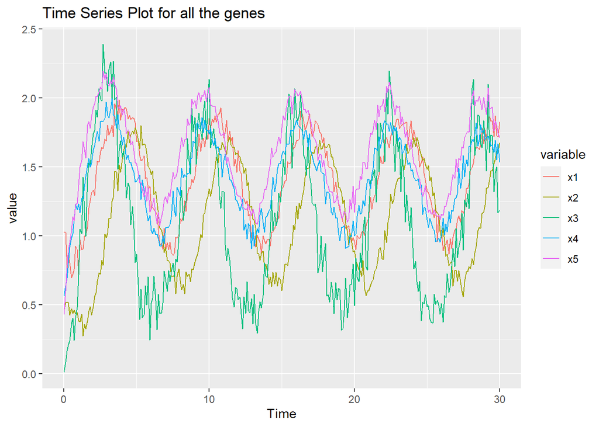

```r
data <- read.csv("genedata.csv")
colnames(data)[1]<-c('Time')  #column name change

meltedData <- melt(data,id='Time')
ggplot(data = meltedData, aes(x=Time, y=value)) + geom_line(aes(colour=variable)) +
  ggtitle('Time Series Plot for all the genes')
```

## Distribution of genes

Lets look at how the genes are distributed.

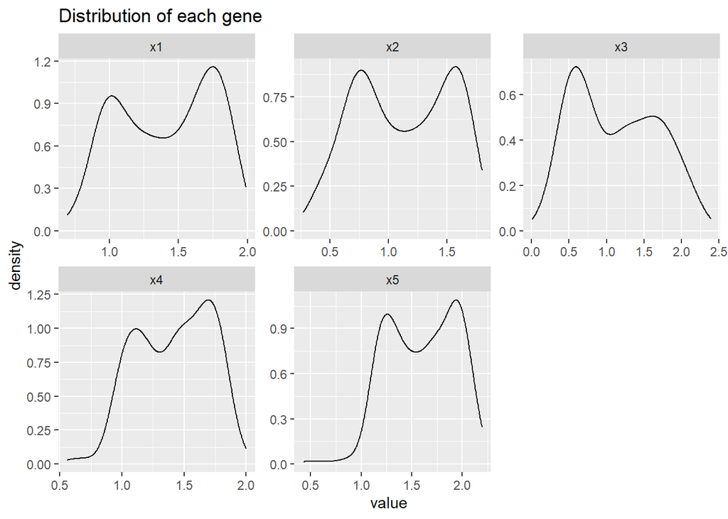

```r
data[,2:6] %>%
  keep(is.numeric) %>%                     # Keep only numeric columns
  gather() %>%                             # Convert to key-value pairs
  ggplot(aes(value)) +                     # Plot the values
    facet_wrap(~ key, scales = "free") +   # In separate panels
    geom_density()+ggtitle('Distribution of each gene')
```

```r
head(data)
```

```
##   Time        x1        x2         x3        x4        x5
## 1  0.0 1.0268834 0.4525760 0.01006418 0.5598125 0.4274130
## 2  0.1 1.0262801 0.5158073 0.08392307 0.6389631 0.5986789
## 3  0.2 0.7642321 0.5197737 0.16395952 0.6934493 0.7904950
## 4  0.3 0.8717433 0.5167898 0.20829830 0.7982659 0.8988766
## 5  0.4 0.8058304 0.4259886 0.23927017 0.9151582 0.9474713
## 6  0.5 0.6965125 0.4693196 0.36445269 0.9857926 1.0403834
```

## Scatter Plot

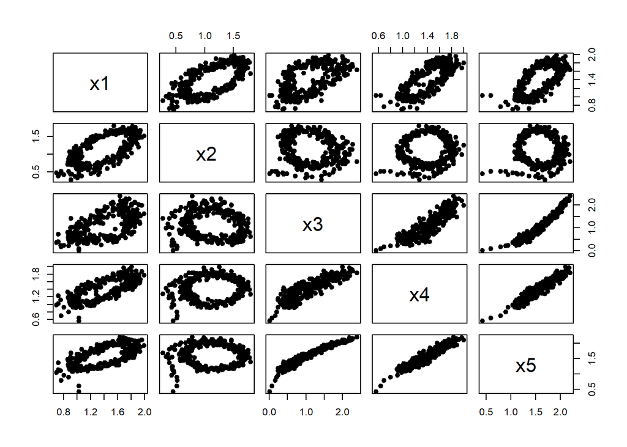

```r
pairs(data[,2:6], pch = 19)
```

## Correlation Plot

We would see at the correlation plot for all the genes to check if these genes have significant correlation with time or other genes.

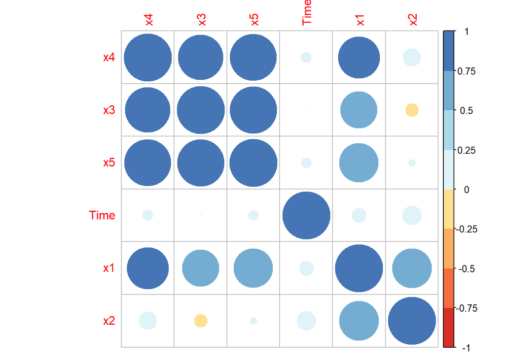

```r
corr <-cor(data)
corrplot(corr, order="hclust",
         col=brewer.pal(n=8, name="RdYlBu"))
```

# Dimensionality Reduction

In this section we will reduce the dimensions of the data i.e from 5 dimensions to 2 dimensions. Here we have used single value decomposition as a method of choice. In R, prcomp uses single value decomposition for dimensionality reduction.

```r
data.pca<- prcomp(data[,2:6])
summary(data.pca)
```

```
## Importance of components:
##                           PC1    PC2     PC3     PC4     PC5
## Standard deviation     0.7498 0.4704 0.11320 0.07515 0.03175
## Proportion of Variance 0.7002 0.2756 0.01596 0.00703 0.00126
## Cumulative Proportion  0.7002 0.9758 0.99171 0.99874 1.00000
```

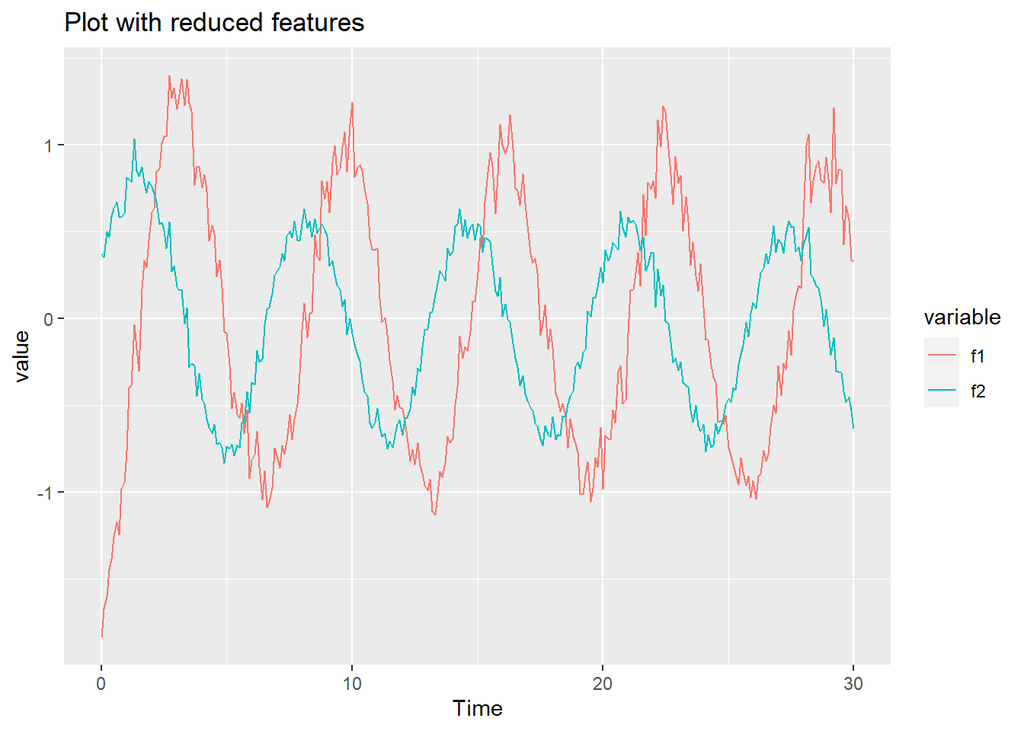

```r
red.data <- as.data.frame(data.pca$x[,1:2]) #Reduced features extraction
red.data$Time = data$Time # Time column addition
colnames(red.data)<-c('f1','f2','Time')

red.melt <- melt(red.data,id='Time')  #Display, reshape
ggplot(data = red.melt, aes(x=Time, y=value)) + geom_line(aes(colour=variable)) +ggtitle('Plot with reduced features')
```

# Modelling

In this section, we will do modeling using non linear regression. We will divide the data in two parts i.e train and test.

```r
set.seed(123)

sampSize <- floor(0.80 * nrow(data)) #sampling
train_ind <- sample(seq_len(nrow(data)), size = sampSize)
train <- data[train_ind, ] # test train split
test <- data[-train_ind, ]

cat('Shape of train: ',dim(train))
```

```
## Shape of train:  240 6
```

```r
cat('\nShape of test: ',dim(test))
```

```
##
## Shape of test:  61 6
```

## Iterative approach

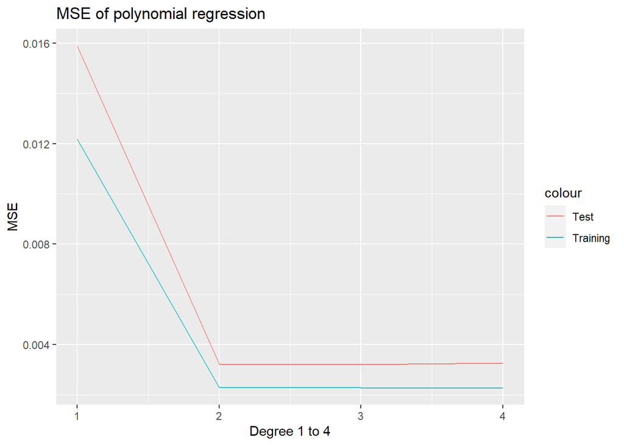

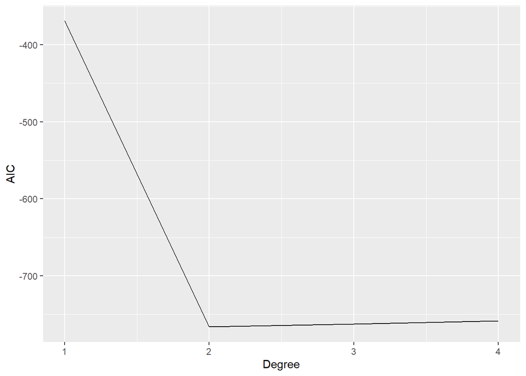

```r
polySelector <- function(train, test){

  trainMSE <- c()
  testMSE <- c()
  AIC.list <- c()

  for (i in 1:4){
    model = lm(data=train,formula=x3~poly(x4,degree = i)+poly(x5,degree = i))

    AIC.list[i] <- AIC(model)

    trainPreds = predict(model,train)
    testPreds = predict(model,test)

    trainMSE[i] <- mean( (train$x3-trainPreds)^2 )
    testMSE[i] <- mean( (test$x3-testPreds)^2 )
  }

  results <- data.frame(training=trainMSE,test=testMSE,ind=c(1:4))

  MSEPlot <- ggplot(results,aes(ind))+
    geom_line(aes(y=trainMSE,colour='Training'))+
    geom_line(aes(y=testMSE,colour='Test'))+
    ggtitle('MSE of polynomial regression')+
    xlab('Degree 1 to 4')+ylab('MSE')
  print(MSEPlot)

  aicBic <- data.frame(AIC=AIC.list,ind=c(1:4))
  ggplot(aicBic)+geom_line(aes(x=ind,y=AIC))+xlab('Degree')
}

polySelector(train,test)
```

Here we can see that the polynomial degree of two gives the lowest MSE on test and trained data. Therefore we will select the degree of two and the model structure would be:

$x_3 = w_0+a_1x_4+a2x_4^2+b_1x_5+b_2x_5^2+e$, where $e$ is gaussian noise.

The AIC score is also lowest for model structure of degree 2 and therefore is the most good fit.

## Residula normality test

We need to see of the residuals are guassian and for that we do Q-Q plot and we can see from plot below the residuals are near guassian.

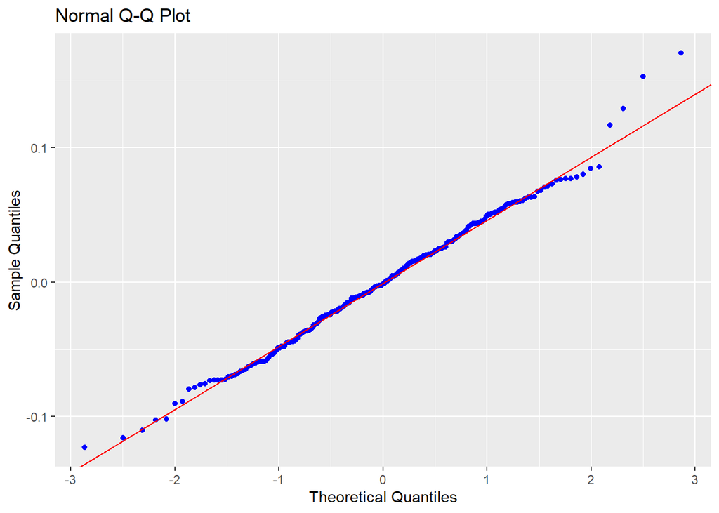

```r
model = lm(data=train, x3~poly(x4,degree = 2)+poly(x5,degree = 2))
ols_plot_resid_qq(model)
```

## Parameter estimation

lm() uses ordinary least sqaures for parameter estimation and hence the parameter estimated are:

$x_3 = 1.1390 -4.62x_4+0.28x_4^2+12.95x_5+1.28x_5^2$

```r
model = lm(data=train, x3~poly(x4,degree = 2)+poly(x5,degree = 2))
model
```

```
##
## Call:
## lm(formula = x3 ~ poly(x4, degree = 2) + poly(x5, degree = 2),
##     data = train)
##
## Coefficients:
##           (Intercept)  poly(x4, degree = 2)1  poly(x4, degree = 2)2
##                1.1390                -4.6230                 0.2822
## poly(x5, degree = 2)1  poly(x5, degree = 2)2
##               12.9514                 1.2884
```

## Covariance matrix

```r
covMat <- vcov(model)

rownames(covMat)<-c('wo','a1','a2','b1','b2')
colnames(covMat) <- c('wo','a1','a2','b1','b2')
print(covMat)
```

```
##               wo            a1            a2            b1            b2
## wo  9.724522e-06  1.393151e-19  6.598815e-20 -1.359000e-19 -6.146860e-20
## a1  1.393151e-19  3.054132e-02  5.117957e-04 -2.934904e-02 -6.226435e-04
## a2  6.598815e-20  5.117957e-04  9.733619e-03 -4.815386e-04 -8.488595e-03
## b1 -1.359000e-19 -2.934904e-02 -4.815386e-04  3.053721e-02  5.893768e-04
## b2 -6.146860e-20 -6.226435e-04 -8.488595e-03  5.893768e-04  9.737725e-03
```

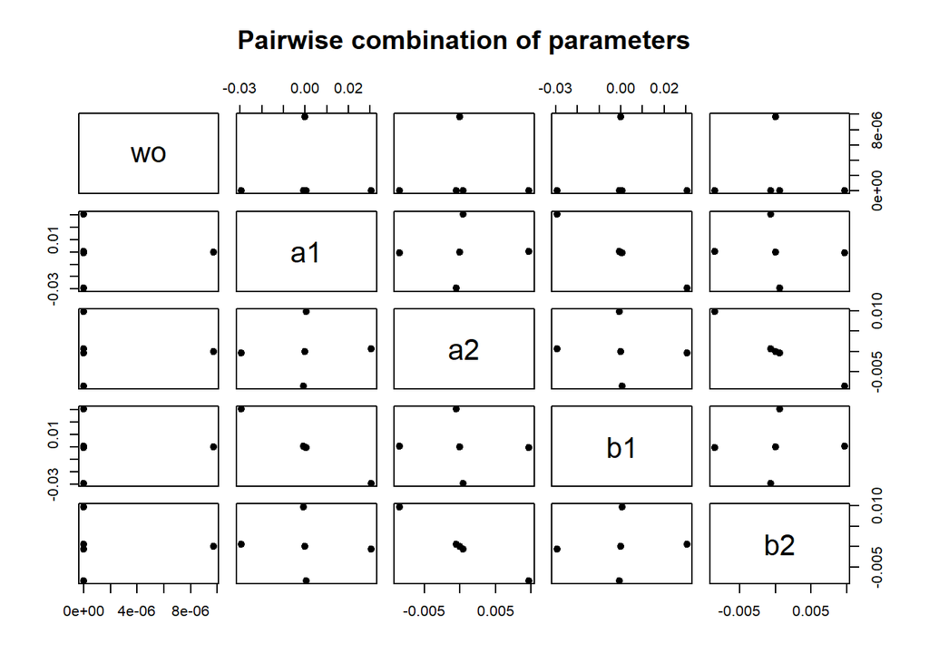

```r
pairs(covMat, pch = 19,main='Pairwise combination of parameters')
```

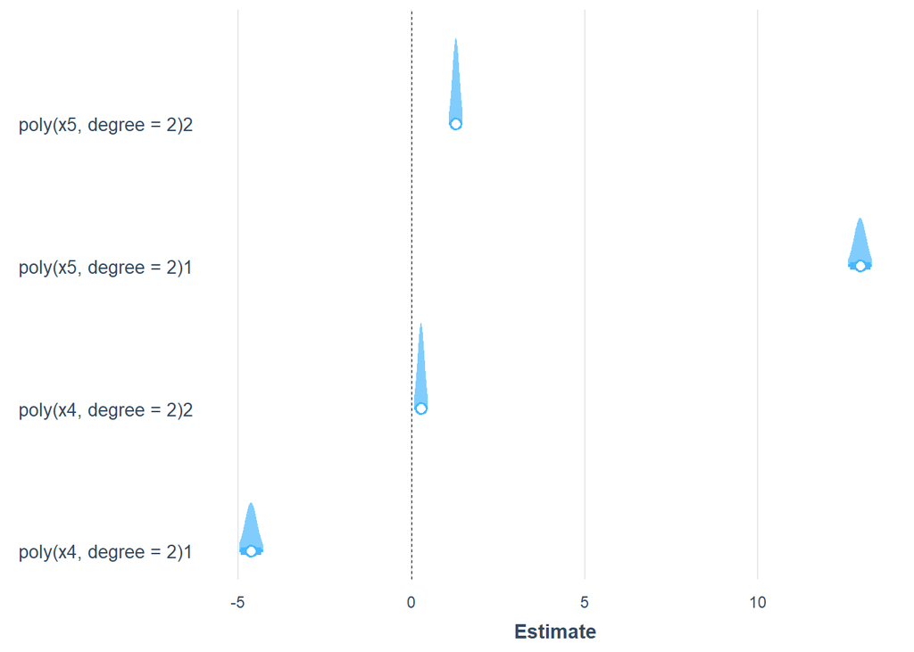

```r
plot_summs(model, scale = FALSE, plot.distributions = TRUE, inner_ci_level = .9,main='Paramter uncertainity')
```

## Prediction

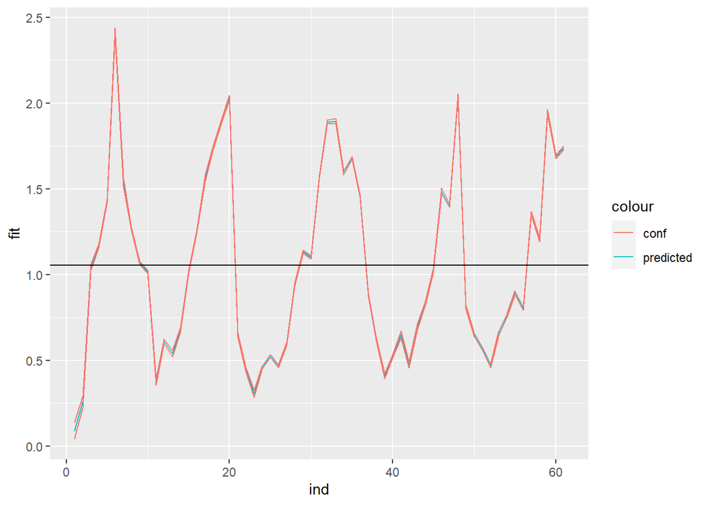

```r
testpreds = as.data.frame( predict(model, newdata = test, interval = "confidence") )
testpreds$ind= c(1:dim(testpreds)[1])  # by default 95 confidence

ggplot(testpreds)+geom_line(aes(x=ind,y=fit,colour='predicted'))+
  geom_line(aes(x=ind,y=upr,colour='conf'))+
  geom_line(aes(x=ind,y=lwr,colour='conf'))+
  geom_hline(yintercept = mean(testpreds$fit))
```

## Model Validation

This section uses K-fold cross validation (with 10 iterations) technique for validating the model

```r
set.seed(123)
train.control <- trainControl(method = "cv", number = 10)

model <- train(x3~poly(x4,degree = 2)+poly(x5,degree = 2), data = data, method = "lm",
               trControl = train.control)
# Summarize the results
print(model)
```

```
## Linear Regression
##
## 301 samples
##   2 predictor
##
## No pre-processing
## Resampling: Cross-Validated (10 fold)
## Summary of sample sizes: 272, 269, 270, 272, 269, 271, ...
## Resampling results:
##
##   RMSE        Rsquared   MAE
##   0.04997768  0.9926197  0.03966265
##
## Tuning parameter 'intercept' was held constant at a value of TRUE
```

RMSE of 0.049 was found by 10-fold cross-validation.

## Approximate Baysian Computation

```r
library(rstanarm)
#install.packages("bayestestR")
library(latticeExtra)
library(bayestestR)
model <- stan_glm(x3~poly(x4,degree = 2)+poly(x5,degree = 2), data=data)
describe_posterior(model)
```

```
## Possible multicollinearity between poly(x5, degree = 2)2 and poly(x4, degree = 2)2 (r = 0.88). This might lead to inappropriate results. See 'Details' in '?rope'.
```

```
## # Description of Posterior Distributions
##
## Parameter             | Median | CI | CI_low | CI_high |    pd | ROPE_CI | ROPE_low | ROPE_high | ROPE_Percentage |  Rhat |  ESS
## --------------------------------------------------------------------------------------------------------------------------------
## (Intercept)           |  1.121 | 89 |  1.117 |   1.126 | 1.000 |      89 |   -0.056 |     0.056 |           0.000 | 1.000 | 4155
## poly(x4, degree = 2)1 | -5.182 | 89 | -5.474 |  -4.908 | 1.000 |      89 |   -0.056 |     0.056 |           0.000 | 1.002 | 2137
## poly(x4, degree = 2)2 |  0.167 | 89 | -0.004 |   0.335 | 0.939 |      89 |   -0.056 |     0.056 |           0.105 | 1.002 | 2578
## poly(x5, degree = 2)1 | 14.462 | 89 | 14.165 |  14.732 | 1.000 |      89 |   -0.056 |     0.056 |           0.000 | 1.003 | 2133
## poly(x5, degree = 2)2 |  1.624 | 89 |  1.454 |   1.791 | 1.000 |      89 |   -0.056 |     0.056 |           0.000 | 1.002 | 2634
```

### Marginal Distribution

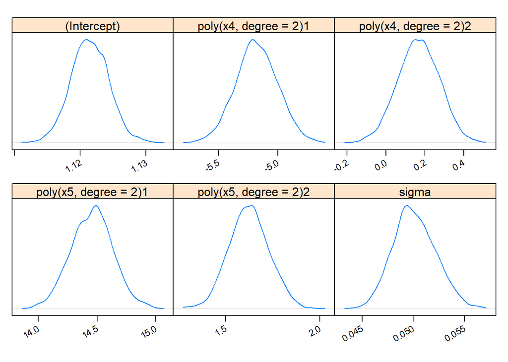

```r
library(latticeExtra)
marginal.plot(model)
```